# Petroleum Products Sales Predictin

## Import Libraries

```python
from datetime import datetime
import numpy as np             #for numerical computations like log,exp,sqrt etc
import pandas as pd            #for reading & storing data, pre-processing
import matplotlib.pylab as plt #for visualization
#for making sure matplotlib plots are generated in Jupyter notebook itself
%matplotlib inline
from statsmodels.tsa.stattools import adfuller
from statsmodels.tsa.stattools import acf, pacf
from statsmodels.tsa.seasonal import seasonal_decompose
from statsmodels.tsa.arima_model import ARIMA
from matplotlib.pylab import rcParams
import seaborn as sns
rcParams['figure.figsize'] = 10, 6
```

## Read Data

```python
data = pd.read_excel('Petroleum.xlsx')
data.head()
```

|  | emirate | product | unit | year | value |
| --- | --- | --- | --- | --- | --- |
| 0 | Abu Dhabi | L.P.G | Metric Tonne \ Yearly | 2013 | 199264 |
| 1 | Abu Dhabi | Unleaded Gasoline\98 | Metric Tonne \ Yearly | 2013 | 51220 |
| 2 | Abu Dhabi | Unleaded Gasoline\95 | Metric Tonne \ Yearly | 2013 | 1931614 |
| 3 | Abu Dhabi | E Plus 91 | Metric Tonne \ Yearly | 2013 | 556363 |
| 4 | Abu Dhabi | kerosene | Metric Tonne \ Yearly | 2013 | 1964 |

```python
data['year'] = pd.to_datetime(data['year'], format='%Y')
```

```python
print("shape of date", data.shape)
```

```
shape of date (618, 5)
```

```python
data.isnull().sum()
```

```
emirate    0
product    0
unit       0
year       0
value      0
dtype: int64
```

```python
data.describe().transpose()
```

|  | count | mean | std | min | 25% | 50% | 75% | max |
| --- | --- | --- | --- | --- | --- | --- | --- | --- |
| value | 618.0 | 185970.745955 | 648785.322964 | 0.0 | 0.0 | 3141.0 | 46723.5 | 5263374.0 |

```python
data.info()
```

```
<class 'pandas.core.frame.DataFrame'>
RangeIndex: 618 entries, 0 to 617
Data columns (total 5 columns):
 #   Column   Non-Null Count  Dtype
---  ------   --------------  -----
 0   emirate  618 non-null    object
 1   product  618 non-null    object
 2   unit     618 non-null    object
 3   year     618 non-null    datetime64[ns]
 4   value    618 non-null    int64
dtypes: datetime64[ns](1), int64(1), object(3)
memory usage: 24.3+ KB
```

```python
data.drop(['emirate'], axis=1, inplace=True)
data.drop(['product'], axis=1, inplace=True)
data.drop(['unit'], axis=1, inplace=True)
```

```python
data.head()
```

|  | year | value |
| --- | --- | --- |
| 0 | 2013-01-01 | 199264 |
| 1 | 2013-01-01 | 51220 |
| 2 | 2013-01-01 | 1931614 |
| 3 | 2013-01-01 | 556363 |
| 4 | 2013-01-01 | 1964 |

```python
#Parse strings to datetime type
data['year'] = pd.to_datetime(data['year'],infer_datetime_format=True) #convert from string to datetime
indexedDataset = data.set_index(['year'])
indexedDataset.head(5)
```

| year | value |
| --- | --- |
| 2013-01-01 | 199264 |
| 2013-01-01 | 51220 |
| 2013-01-01 | 1931614 |
| 2013-01-01 | 556363 |
| 2013-01-01 | 1964 |

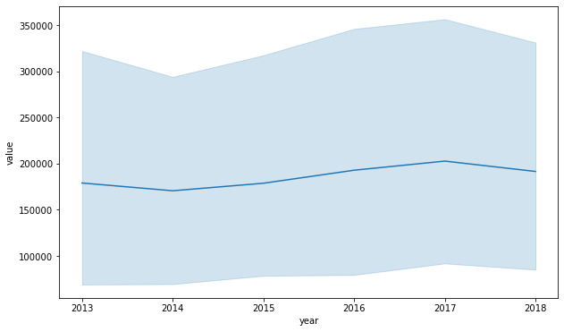

```python
sns.lineplot(x='year',y='value', data=df)
plt.show()
```

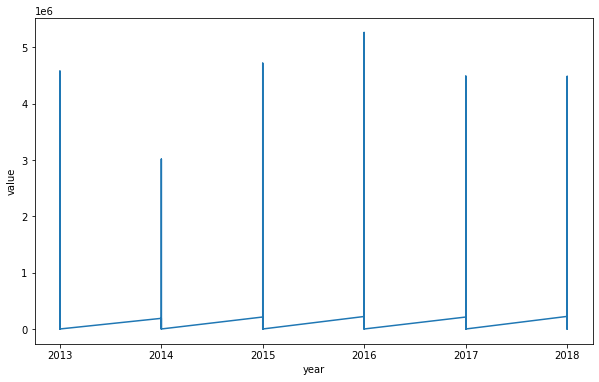

```python
## plot graph
plt.xlabel('year')
plt.ylabel('value')
plt.plot(indexedDataset)
```

```python
#Determine rolling statistics
rolmean = indexedDataset.rolling(window=12).mean() #window size 12 denotes 12 months, giving rolling mean at yearly level
rolstd = indexedDataset.rolling(window=12).std()
print(rolmean,rolstd)
```

```
                   value
year
2013-01-01           NaN
2013-01-01           NaN
2013-01-01           NaN
2013-01-01           NaN
2013-01-01           NaN
...                  ...
2018-01-01  56878.666667
2018-01-01  57194.083333
2018-01-01  39493.916667
2018-01-01  38966.250000
2018-01-01  37441.083333

[618 rows x 1 columns]                    value
year
2013-01-01           NaN
2013-01-01           NaN
2013-01-01           NaN
2013-01-01           NaN
2013-01-01           NaN
...                  ...
2018-01-01  94661.227896
2018-01-01  94460.568782
2018-01-01  81782.919184
2018-01-01  82036.366727
2018-01-01  82623.496512

[618 rows x 1 columns]
```

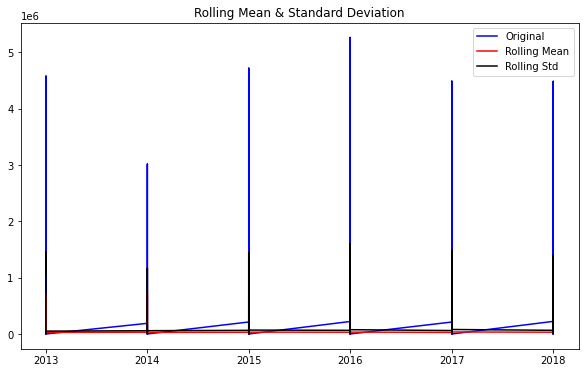

```python
#Plot rolling statistics
orig = plt.plot(indexedDataset, color='blue', label='Original')
mean = plt.plot(rolmean, color='red', label='Rolling Mean')
std = plt.plot(rolstd, color='black', label='Rolling Std')
plt.legend(loc='best')
plt.title('Rolling Mean & Standard Deviation')
plt.show(block=False)
```

From the above graph, we see that rolling mean itself has a constant line with time, also rolling standard deviation is fairly constant with time. For our time series to be stationary, we need to ensure that both the rolling statistics ie: mean & std. dev. remain time invariant or constant with time. Thus the curves for both of is parallel to the x-axis, which in our case is stationary.

perform the ADCF test for further information:

```python
#Perform Augmented Dickey–Fuller test:
print('Results of Dickey Fuller Test:')
dftest = adfuller(indexedDataset['value'], autolag='AIC')

dfoutput = pd.Series(dftest[0:4], index=['Test Statistic','p-value','#Lags Used','Number of Observations Used'])
for key,value in dftest[4].items():
    dfoutput['Critical Value (%s)'%key] = value

print(dfoutput)
```

```
Results of Dickey Fuller Test:
Test Statistic                  -4.215863
p-value                          0.000619
#Lags Used                      19.000000
Number of Observations Used    598.000000
Critical Value (1%)             -3.441333
Critical Value (5%)             -2.866385
Critical Value (10%)            -2.569350
dtype: float64
```

For a Time series to be stationary, its ADCF test should have:

1- p-value to be low (according to the null hypothesis)

2- The critical values at 1%,5%,10% confidence intervals should be as close as possible to the Test Statistics